# Machine Learning Prediction Assignment

Raheel

15/06/2020

# Background

> In this project, the goal is to use data from accelerometers of 6 participants who were asked to perform barbell lifts correctly and incorrectly in 5 different ways. Class A corresponds to the specified execution of the exercise, while the other 4 classes correspond to common mistakes. For more detail of the data for this project the souce is: http://groupware.les.inf.puc-rio.br/har. The goal of the project is to predict the manner in which the participants did the exercise. This is the “classe” variable in the training set and the predicted model is applied to predict 20 different test cases.

### Loading necessary Libraries

```r
library(lattice)
library(ggplot2)
library(caret)
library(rpart)
library(rpart.plot)
library(corrplot)
library(rattle)
library(randomForest)
library(RColorBrewer)
library(e1071)
set.seed(4321)
```

### Loading Data sets

```r
traindata_url <- "http://d396qusza40orc.cloudfront.net/predmachlearn/pml-training.csv"
testdata_url <- "http://d396qusza40orc.cloudfront.net/predmachlearn/pml-testing.csv"
train_data <- read.csv(url(traindata_url), strip.white = TRUE, na.strings = c("NA",""))
test_data  <- read.csv(url(testdata_url),  strip.white = TRUE, na.strings = c("NA",""))
```

## Exploring Data

```r
dim(train_data)
```

```
## [1] 19622   160
```

#### Creating data partition for training and testing data

```r
in_train  <- createDataPartition(train_data$classe, p=0.75, list=FALSE)
train_set <- train_data[ in_train, ]
test_set  <- train_data[-in_train, ]
dim(train_set)
```

```
## [1] 14718   160
```

```r
dim(test_set)
```

```
## [1] 4904  160
```

```r
nzv_var <- nearZeroVar(train_set)
train_set <- train_set[ , -nzv_var]
test_set  <- test_set [ , -nzv_var]
dim(train_set)
```

```
## [1] 14718   120
```

```r
dim(test_set)
```

```
## [1] 4904  120
```

> Now removing the variables that are mostly NA. A threshlod of 95 % is selected.

```r
na_var <- sapply(train_set, function(x) mean(is.na(x))) > 0.95
train_set <- train_set[ , na_var == FALSE]
test_set  <- test_set [ , na_var == FALSE]
dim(train_set)
```

```
## [1] 14718    59
```

```r
dim(test_set)
```

```
## [1] 4904   59
```

> > Since the columns 1 to 5 are identification variables only so they are to be removed as well.

```r
train_set <- train_set[ , -(1:5)]
test_set  <- test_set [ , -(1:5)]
dim(train_set)
```

```
## [1] 14718    54
```

```r
dim(test_set)
```

```
## [1] 4904   54
```

### Correlation Analysis

> > Perform a correlation analysis between the variables before the modeling work itself is done. Select “FPC” for the first principal component order.

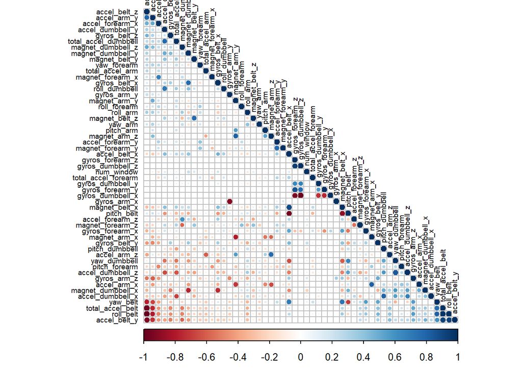

```r
corr_matrix <- cor(train_set[ , -54])
corrplot(corr_matrix, order = "FPC", method = "circle", type = "lower",
         tl.cex = 0.6, tl.col = rgb(0, 0, 0))
```

> > If two variables are highly correlated their colors are either dark blue (for a positive correlation) or dark red (for a negative corraltions). To further reduce the number of variables, a Principal Components Analysis (PCA) could be performed as the next step. However, since there are only very few strong correlations among the input variables,the PCA will not be performed. Instead, a few different prediction models will be built next.

# Prediction Models

## Decision Tree Model

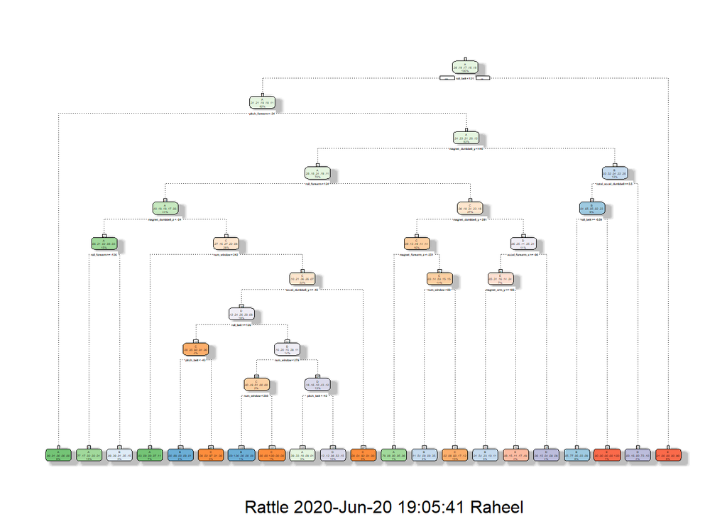

```r
set.seed(1813)
fit_decision_tree <- rpart(classe ~ ., data = train_set, method="class")
fancyRpartPlot(fit_decision_tree)
```

### Predictions of the decision tree model on test_set.

```r
predict_decision_tree <- predict(fit_decision_tree, newdata = test_set, type="class")
conf_matrix_decision_tree <- confusionMatrix(predict_decision_tree, test_set$classe)
conf_matrix_decision_tree
```

```
## Confusion Matrix and Statistics
##
##           Reference
## Prediction    A    B    C    D    E
##          A 1253  165   43   48   43
##          B   49  589   67   54  103
##          C   17   59  674  127   67
##          D   57  106   50  536  106
##          E   19   30   21   39  582
##
## Overall Statistics
##
##                Accuracy : 0.741
##                  95% CI : (0.7285, 0.7532)
##     No Information Rate : 0.2845
##     P-Value [Acc > NIR] : < 2.2e-16
##
##                   Kappa : 0.6713
##
##  Mcnemar's Test P-Value : < 2.2e-16
##
## Statistics by Class:
##
##                      Class: A Class: B Class: C Class: D Class: E
## Sensitivity            0.8982   0.6207   0.7883   0.6667   0.6459
## Specificity            0.9148   0.9310   0.9333   0.9222   0.9728
## Pos Pred Value         0.8073   0.6833   0.7140   0.6269   0.8423
## Neg Pred Value         0.9576   0.9109   0.9543   0.9338   0.9243
## Prevalence             0.2845   0.1935   0.1743   0.1639   0.1837
## Detection Rate         0.2555   0.1201   0.1374   0.1093   0.1187
## Detection Prevalence   0.3165   0.1758   0.1925   0.1743   0.1409
## Balanced Accuracy      0.9065   0.7758   0.8608   0.7944   0.8094
```

#### Plot the predictive accuracy of the decision tree model.

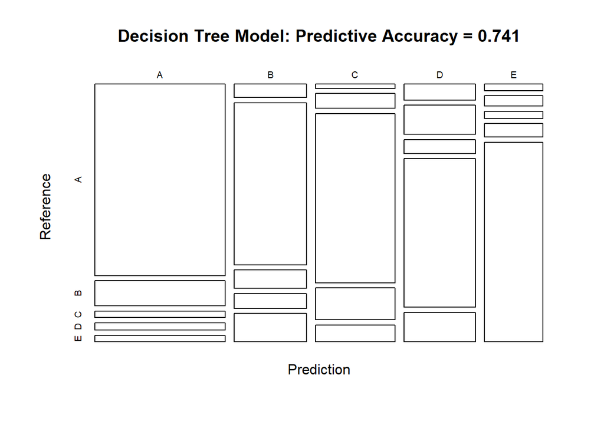

```r
plot(conf_matrix_decision_tree$table, col = conf_matrix_decision_tree$byClass,
     main = paste("Decision Tree Model: Predictive Accuracy =",
                  round(conf_matrix_decision_tree$overall['Accuracy'], 4)))
```

## Support Vector Machine

```r
SVM = svm(formula = classe ~ .,
          data = train_set,
          type = 'C-classification',
          kernel = 'linear')

predict_SVM <- predict(SVM, newdata = test_set)
conf_matrix_SVM <- confusionMatrix(predict_SVM, test_set$classe)
conf_matrix_SVM
```

```
## Confusion Matrix and Statistics
##
##           Reference
## Prediction    A    B    C    D    E
##          A 1287  134   63   57   42
##          B   27  672   81   34  109
##          C   30   58  656   88   71
##          D   42   17   31  585   47
##          E    9   68   24   40  632
##
## Overall Statistics
##
##                Accuracy : 0.7814
##                  95% CI : (0.7696, 0.7929)
##     No Information Rate : 0.2845
##     P-Value [Acc > NIR] : < 2.2e-16
##
##                   Kappa : 0.7221
##
##  Mcnemar's Test P-Value : < 2.2e-16
##
## Statistics by Class:
##
##                      Class: A Class: B Class: C Class: D Class: E
## Sensitivity            0.9226   0.7081   0.7673   0.7276   0.7014
## Specificity            0.9156   0.9365   0.9390   0.9666   0.9648
## Pos Pred Value         0.8130   0.7281   0.7265   0.8102   0.8176
## Neg Pred Value         0.9675   0.9304   0.9503   0.9476   0.9349
## Prevalence             0.2845   0.1935   0.1743   0.1639   0.1837
## Detection Rate         0.2624   0.1370   0.1338   0.1193   0.1289
## Detection Prevalence   0.3228   0.1882   0.1841   0.1472   0.1576
## Balanced Accuracy      0.9191   0.8223   0.8531   0.8471   0.8331
```

#### Plot the predictive accuracy of the SVM model.

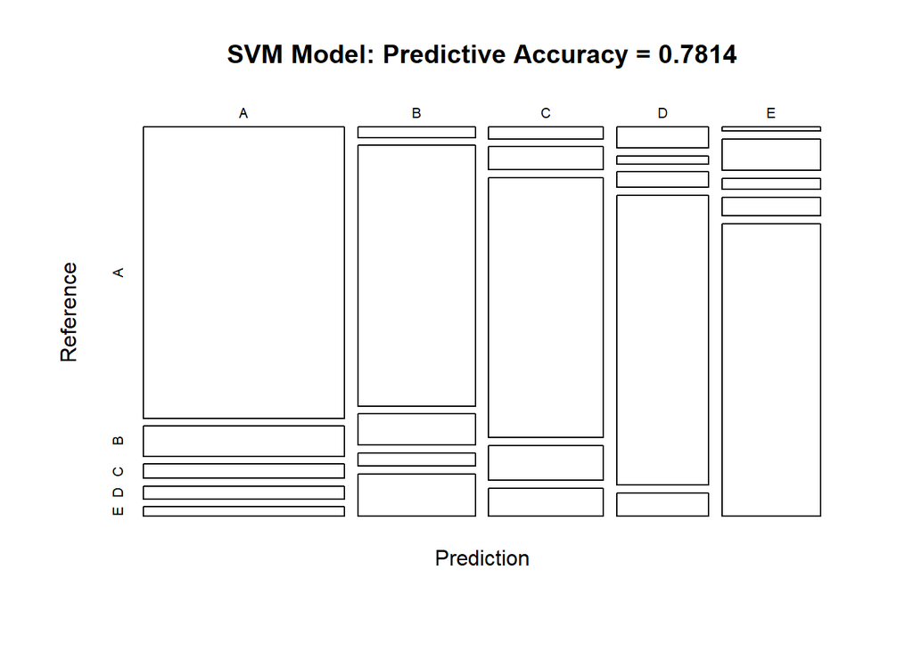

```r
plot(conf_matrix_SVM$table, col = conf_matrix_SVM$byClass,
     main = paste("SVM Model: Predictive Accuracy =",
                  round(conf_matrix_SVM$overall['Accuracy'], 4)))
```

## Random Forest Model

```r
set.seed(1813)
ctrl_RF <- trainControl(method = "repeatedcv", number = 5, repeats = 2)
fit_RF  <- train(classe ~ ., data = train_set, method = "rf",
                 trControl = ctrl_RF, verbose = FALSE)
fit_RF$finalModel
```

```
##
## Call:
##  randomForest(x = x, y = y, mtry = param$mtry, verbose = FALSE)
##                Type of random forest: classification
##                      Number of trees: 500
## No. of variables tried at each split: 27
##
##         OOB estimate of  error rate: 0.2%
## Confusion matrix:
##      A    B    C    D    E  class.error
## A 4183    1    0    0    1 0.0004778973
## B    4 2840    3    1    0 0.0028089888
## C    0    4 2562    1    0 0.0019477990
## D    0    0    8 2403    1 0.0037313433
## E    0    0    0    5 2701 0.0018477458
```

#### Predictions of the Random Forest model on test_set.

```r
predict_RF <- predict(fit_RF, newdata = test_set)
conf_matrix_RF <- confusionMatrix(predict_RF, test_set$classe)
conf_matrix_RF
```

```
## Confusion Matrix and Statistics
##
##           Reference
## Prediction    A    B    C    D    E
##          A 1395    2    0    0    0
##          B    0  945    4    0    0
##          C    0    2  851    6    0
##          D    0    0    0  798    3
##          E    0    0    0    0  898
##
## Overall Statistics
##
##                Accuracy : 0.9965
##                  95% CI : (0.9945, 0.998)
##     No Information Rate : 0.2845
##     P-Value [Acc > NIR] : < 2.2e-16
##
##                   Kappa : 0.9956
##
##  Mcnemar's Test P-Value : NA
##
## Statistics by Class:
##
##                      Class: A Class: B Class: C Class: D Class: E
## Sensitivity            1.0000   0.9958   0.9953   0.9925   0.9967
## Specificity            0.9994   0.9990   0.9980   0.9993   1.0000
## Pos Pred Value         0.9986   0.9958   0.9907   0.9963   1.0000
## Neg Pred Value         1.0000   0.9990   0.9990   0.9985   0.9993
## Prevalence             0.2845   0.1935   0.1743   0.1639   0.1837
## Detection Rate         0.2845   0.1927   0.1735   0.1627   0.1831
## Detection Prevalence   0.2849   0.1935   0.1752   0.1633   0.1831
## Balanced Accuracy      0.9997   0.9974   0.9967   0.9959   0.9983
```

## Results on Test Set

```r
predict_quiz <- predict(fit_RF, newdata = test_data)
predict_quiz
```

```
##  [1] B A B A A E D B A A B C B A E E A B B B
## Levels: A B C D E
```